# 03.01_causal_inference-balance_check

- Version: 1.0
- last update: 2023-12-08
- Short description: This notebook is used to conduct covariance balance checks.

## Install and Import

## Notebook Details

## Configuration

## Load Data

```
(107, 147)
```

## Main Part

### Filter data

```
Filtered DataFrame:
<class 'pandas.core.frame.DataFrame'>
RangeIndex: 107 entries, 0 to 106
Data columns (total 12 columns):
 #   Column                      Non-Null Count  Dtype
---  ------                      --------------  -----
 0   age_clean                   107 non-null    float64
 1   sex_clean                   107 non-null    int64
 2   apo_e4_allele_clean         107 non-null    int64
 3   cerad                       107 non-null    int64
 4   education_years             107 non-null    int64
 5   age_at_first_tbi            107 non-null    int64
 6   num_tbi_w_loc               107 non-null    int64
 7   control_set                 107 non-null    int64
 8   ever_tbi_w_loc_clean        107 non-null    int64
 9   longest_loc_duration_clean  107 non-null    float64
 10  group_weight                107 non-null    float64
 11  act_demented_clean          107 non-null    int64
dtypes: float64(3), int64(9)
memory usage: 10.2 KB
```

|  | age_clean | sex_clean | apo_e4_allele_clean | cerad | education_years | age_at_first_tbi | num_tbi_w_loc | control_set | ever_tbi_w_loc_clean | longest_loc_duration_clean | group_weight | act_demented_clean |
| --- | --- | --- | --- | --- | --- | --- | --- | --- | --- | --- | --- | --- |
| 0 | 87.0 | 1 | 0 | 0 | 16 | 0 | 0 | 31 | 0 | 0.0 | 47.75 | 0 |
| 1 | 97.0 | 1 | 0 | 2 | 17 | 12 | 1 | 26 | 1 | 90.0 | 11.54 | 0 |
| 2 | 85.0 | 1 | 1 | 3 | 10 | 72 | 1 | 25 | 1 | 5.5 | 5.66 | 1 |
| 3 | 92.0 | 0 | 0 | 0 | 11 | 87 | 1 | 52 | 1 | 5.5 | 17.31 | 0 |
| 4 | 101.0 | 1 | 1 | 3 | 16 | 0 | 0 | 28 | 0 | 0.0 | 12.31 | 1 |

## Covariance Balance Check

### Balance check: age_clean

- To check for covariate balance using hypothesis testing, we use a **paired t-test** for the continuous variable **age_clean** to determine if there are statistically significant differences between the paired groups (paired by control_set).
- For the categorical variable **sex_clean**, we can use a chi-squared test to check if the distribution of sexes is independent of the groups. However, since we're dealing with paired data, the chi-squared test might not be appropriate because it's typically used for unpaired categorical data. In the case of paired categorical data, McNemar's test is often more appropriate. McNemar's test is used for binary categorical data to determine whether there are differences on a dichotomous dependent variable between two related groups.

```
TtestResult(statistic=-0.06974961418148493, pvalue=0.944682730250705, df=48)
```

The paired t-test for the continuous variable age_clean yields a p-value of approximately 0.945. This high p-value suggests that there is no statistically significant difference in the age_clean variable between the treatment and control groups within the paired data, **indicating that the covariate is balanced with respect to age.**

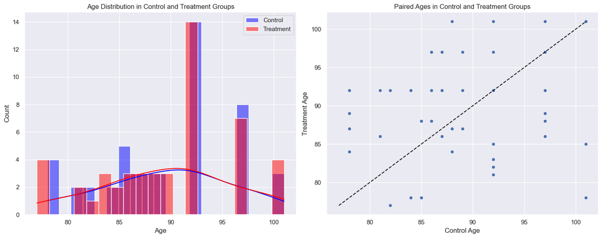

**Histograms (Left Plot):** This plot shows the age distributions of the control (blue) and treatment (red) groups. The overlapping areas indicate where the age ranges of the two groups intersect. This visualization helps to understand the distribution and range of ages in both groups.

**Scatter Plot (Right Plot):** Each point represents a pair of individuals from the control and treatment groups. The closer the points are to the diagonal dashed line, the more similar the ages are within each pair. This plot illustrates the direct age comparisons within each pair.

### Balance check: sex_clean

Conducting **chi-squared test** to compare the distribution of the 'sex_clean' variable between the control and treatment groups:

```
Chi2ContingencyResult(statistic=0.0, pvalue=1.0, dof=1, expected_freq=array([[28., 21.],
       [28., 21.]]))
```

These results indicate that there is no significant difference in the distribution of the 'sex_clean' variable between the control and treatment groups. The chi-squared statistic of (0.0) and the p-value of (1.0) suggest that the observed frequencies in your data perfectly match the expected frequencies under the null hypothesis of no association between group (control or treatment) and sex.

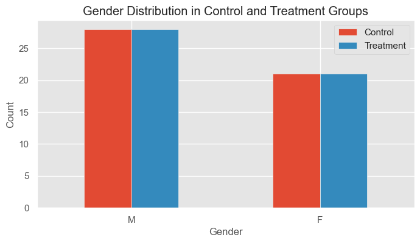

**Bar Plot:** This plot illustrates the counts of each sex in the control and treatment groups. The plot shows an equal distribution of sexes across both groups, which is ideal for a balanced comparison.

### Balance check: apo_e4_allele_clean

- Conducting chi-squared test to compare the distribution of the 'apo_e4_allele_clean' variable between the control and treatment groups:
- Removing the unknown values (-1)

```
Chi2ContingencyResult(statistic=0.0, pvalue=1.0, dof=1, expected_freq=array([[33.5,  8.5],
       [33.5,  8.5]]))
```

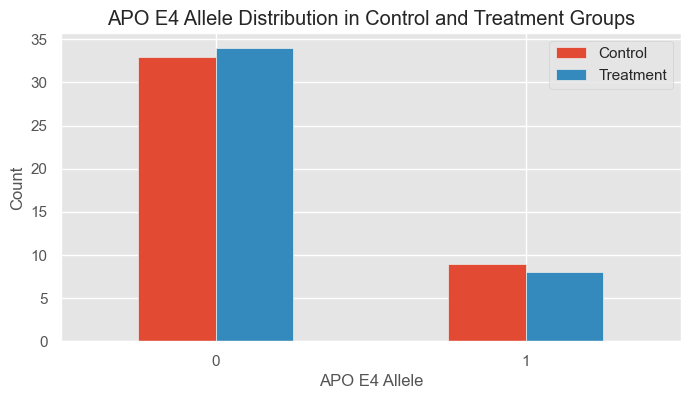

### Balance check: education_years

For the balance check on the continuous variable education_years, we use the paired t-test:

```
TtestResult(statistic=0.14153699201803113, pvalue=0.8880381122818317, df=48)
```

The paired t-test conducted to compare the 'education_years' variable between control and treatment groups yielded a test statistic of (0.14154) and a p-value of (0.88804). These results indicate a minimal difference between the mean years of education in both groups. The high p-value, significantly exceeding the standard alpha level of 0.05, suggests that the observed difference is not statistically significant. With 48 degrees of freedom, the test provides a reliable analysis of the data. In conclusion, the factor differentiating the groups does not appear to have a significant influence on the years of education within the context of this study.

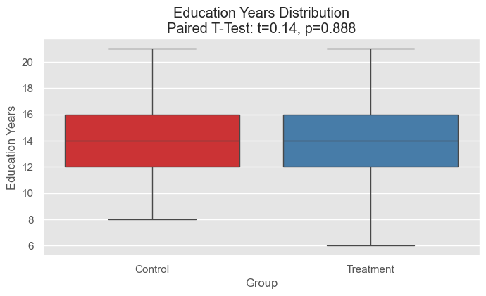

### Balance check: cerad

```
Chi2ContingencyResult(statistic=1.4168412232928362, pvalue=0.7015918467502615, dof=3, expected_freq=array([[10.5, 15.5, 11. , 12. ],
       [10.5, 15.5, 11. , 12. ]]))
```

The Chi-squared test for comparing the 'cerad' variable between control and treatment groups resulted in a chi-squared statistic of (1.41684) and a p-value of (0.70159). These results indicate a low degree of difference between the observed and expected frequencies under the null hypothesis. The test's degrees of freedom, (3), are determined by the number of categories in the 'cerad' variable minus one. The expected frequencies array shows a uniform distribution across both groups, suggesting no significant association between group type and 'cerad'. In summary, the factor differentiating the control and treatment groups does not significantly affect the distribution of the 'cerad' variable within this study.

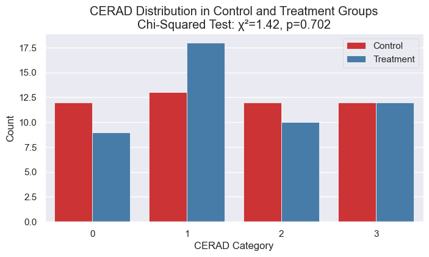

### Balance check: act_demented_clean

```
Chi2ContingencyResult(statistic=0.04096989966555184, pvalue=0.8395960345180435, dof=1, expected_freq=array([[26., 23.],
       [26., 23.]]))
```

The Chi-squared test conducted on the 'act_demented_clean' variable resulted in a chi-squared statistic of approximately (0.041). The associated p-value is (0.840), indicating that there is no significant difference in the distribution of 'act_demented_clean' between the control and treatment groups. The degrees of freedom for the test were (1), reflecting the categorical nature of the variable. The expected frequencies, nearly equal in both groups, match the observed frequencies closely. In summary, these results suggest no statistically significant association between the group type (control or treatment) and the 'act_demented_clean' variable, affirming a balanced distribution between the groups for this variable.

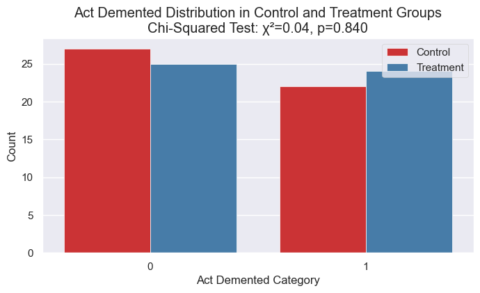

### Balance check: Overview

[output not shown]

**Approach:**

- **T-Test Selection:** Paired t-tests were chosen for continuous variables ('age_clean' and 'education_years') because they are appropriate for comparing means between two related groups.
- **Chi-Squared Test Selection:** Chi-squared tests were selected for categorical variables ('apo_e4_allele_clean', 'sex_clean', 'cerad', and 'act_demented_clean') to assess the distribution and association of categorical data between groups.
- **Filtering:** Filtering was applied to ensure the validity of statistical tests by focusing on matched pairs and excluding records with missing or unspecified values.
- **Balanced Groups:** The objective was to check whether the groups (control and treatment) were balanced in terms of various characteristics, as indicated by non-significant test results.

**Conclusion:**

- For all the tested variables ('age_clean', 'sex_clean', 'apo_e4_allele_clean', 'education_years', 'cerad', and 'act_demented_clean'), the statistical tests did not reveal any significant differences between the control and treatment groups.
- The p-values for all variables were greater than the commonly used significance level of (0.05), indicating that there is no strong evidence to reject the null hypothesis of no significant difference.
- As a result, the conclusion is that the groups in the dataset are balanced with respect to these characteristics, and there are no significant imbalances between the control and treatment groups based on the tested variables.

## Checking the Propensity Scores

Given that we have a paired dataset, the typical use of propensity scores for matching has already been performed.

## Exports

## Watermark

```
Last updated: 2023-11-27T17:13:22.783018+05:30

Python implementation: CPython
Python version       : 3.9.16
IPython version      : 8.16.1

Compiler    : Clang 14.0.6
OS          : Darwin
Release     : 23.1.0
Machine     : arm64
Processor   : arm
CPU cores   : 10
Architecture: 64bit
```

```
numpy     : 1.26.1
pandas    : 2.1.1
seaborn   : 0.13.0
matplotlib: 3.8.0
```

## Snapshot

```
03.01_causal_inference-balance_check.ipynb
[NbConvertApp] Converting notebook 03.01_causal_inference-balance_check.ipynb to html
[NbConvertApp] WARNING | Alternative text is missing on 6 image(s).
[NbConvertApp] Writing 643920 bytes to ../reports/html/2023-11-27_03.01_causal_inference-balance_check.html
```

```
[NbConvertApp] Converting notebook 03.01_causal_inference-balance_check.ipynb to html
[NbConvertApp] WARNING | Alternative text is missing on 6 image(s).
[NbConvertApp] Writing 561789 bytes to ../reports/html/2023-11-27_03.01_causal_inference-balance_check_no_code.html
```

```
0
```